# Weather and Electricity Demand: A Data Analysis of New York City and Long Island (2020–2026)

Author

Energy Team

## Approach

**Group Members:** Bikash Bhowmik, Cecilia De La Fuente Chavez, Ellie Wilser, Zaina Hassan

**Tools for collaboration:**

- Slack
- [Project_3_Energy_Task_Tracker](https://docs.google.com/spreadsheets/d/1LXvVno-vkfswrLjzSeUACgMw807ED2XciFtNPcDoug0/edit?gid=0#gid=0)
- Github

**Data:**

- NYISO data: https://mis.nyiso.com/public/P-58Blist.htm
- NOAA data: https://www.weather.gov/wrh/Climate?wfo=okx
- Time Range: January 2020 to September 2026
- Locations:

| **NYISO Zone** | **NOAA Weather Station** |
| --- | --- |
| NYC (Zone J) | LaGuardia Airport |
| NYC (Zone J) | Central Park |
| Long Island (Zone K) | Islip Airport |

### **Overview**

Project 3 will examine the relationship between weather and electricity load in New York City by combining data from the National Weather Service (NWS) and the New York Independent System Operator (NYISO). Team members will download data covering a shared time range, select relevant variables, and clean the datasets using R, addressing missing values, duplicates, inconsistent formats, and potential outliers.

A PostgreSQL database will be designed to store the weather and electricity data, establish relationships between tables, and support joining the datasets for analysis. Using R, the team will calculate summary statistics, and create visualizations of weather and electricity load over time.

The goal of this project is to explore the relationship between weather and electricity demand while applying practical and diverse skills and tools used by data scientists such as data acquisition, database management, data preparation, exploratory analysis, and visualization.

Throughout the project, members will document data sources, cleaning approach, database design, and analysis methods by collaborating through a shared GitHub repository and Google Drive. Finally all members will review code and findings, and prepare a final presentation.

### **NYISO Dataset**

The plan is to download monthly NYISO electricity load data from January 2020 through September 2026, and filter the data to include New York City (N.Y.C.) and Long Island (LONGIL). Duplicate records and missing values will be checked. Afterwards the timestamps will be converted to calendar dates and the five-minute observations aggregated into daily averages for each location, excluding NAs. The daily averages will be rounded to two decimal places for readability. The final dataset will be saved as a csv called “nyiso_daily_average_load”, ready to be integrated with the weather data and used for further analysis.

### **Weather Dataset**

The plan is to collect daily weather data from NOAA for January 2020 through September 2026 from three stations: LaGuardia Airport, Central Park for NYC (Zone J), and Islip Airport for Long Island (Zone K). Relevant variables will include **daily average, min/max temperature, and precipitation**.

The data will be cleaned using R to address missing values, duplicate records, inconsistent date formats, and potential outliers. Dates will be standardized to match the NYISO electricity load dataset. The cleaned weather data will be saved as a CSV file and integrated with the daily electricity load data to explore relationships between weather conditions and electricity demand.

The NOAA weather dataset combines observations from three stations: LaGuardia Airport, Central Park, and Islip Airport, covering 7,395 records. Three new columns were added: **TAVG** (average temperature), **HDD** (heating degree days), and **CDD** (cooling degree days). The data was processed in R, and the cleaned dataset was saved as a new CSV file for integration with the NYISO electricity load data.

### **Database Design**

After the NYISO and weather data are cleaned and prepared for analysis, new normalized tables will be structured to satisfy the following criteria:

- 1NF: Each table cell must contain a single, atomic (indivisible) value, and every record must be unique.
- 2NF: The table must already be in 1NF, and every non-key column must depend on the entire primary key (no partial dependencies).
- 3NF: The table must already be in 2NF, and there must be no transitive dependencies.

Accompanying the normalized tables, an entity-relationship diagram (ERD) will be created to visualize the database structure and attribute details. This will be accomplished using Mermaid code blocks embedded directly within Quarto documents to render the diagrams from text.

Once the tables are normalized and documented, they will be loaded into a PostgreSQL server, ensuring the schema defined in the ERD is directly reflected in the SQL table creation scripts.

### **Analysis**

The analysis will be conducted using R and the packages within such as dplyr, tidyr, and ggplot2. These packages are the foundation for data manipulation, summary statistics, and visualization. Once the weather and electricity datasets have been cleaned and integrated, we will explore the relationship between weather conditions and electricity load in New York City. Since the weather data is recorded daily, electricity load observations will be aggregated to a daily level to allow for consistent comparisons.

[output not shown]

## Code

### Loading Weather Data (Member 1)

#### Select weather stations and date range

```r
# 1. Import the existing combined CSV file
weather <- read_csv(
  "https://raw.githubusercontent.com/EllieWilser/Project-3/refs/heads/main/NOAA_Weather_All_Three_Stations.csv",
  show_col_types = FALSE
)
```

#### Identify relevant variables (date, temperature, precipitation)

```r
# 2. Check the data
print(dim(weather))
```

```
[1] 7395    8
```

```r
print(names(weather))
```

```
[1] "STATION"      "NAME"         "DATE"         "PRCP"         "TMAX"
[6] "TMIN"         "STATION_NAME" "NYISO_ZONE"
```

```r
glimpse(weather)
```

```
Rows: 7,395
Columns: 8
$ STATION      <chr> "USW00014732", "USW00014732", "USW00014732", "USW00014732…
$ NAME         <chr> "LAGUARDIA AIRPORT, NY US", "LAGUARDIA AIRPORT, NY US", "…
$ DATE         <date> 2020-01-01, 2020-01-02, 2020-01-03, 2020-01-04, 2020-01-…
$ PRCP         <dbl> 0.00, 0.00, 0.14, 0.24, 0.00, 0.02, 0.00, 0.00, 0.00, 0.0…
$ TMAX         <dbl> 42, 49, 49, 50, 41, 44, 44, 43, 34, 53, 66, 67, 45, 44, 5…
$ TMIN         <dbl> 35, 34, 45, 41, 36, 32, 35, 28, 24, 33, 48, 44, 37, 39, 4…
$ STATION_NAME <chr> "LaGuardia Airport", "LaGuardia Airport", "LaGuardia Airp…
$ NYISO_ZONE   <chr> "NYC", "NYC", "NYC", "NYC", "NYC", "NYC", "NYC", "NYC", "…
```

#### Import weather data into R

```r
# 3. Standardize data types and filter the date range
weather_clean <- weather %>%
  mutate(
    STATION = as.character(STATION),
    DATE = as.Date(
      as.character(DATE),
      tryFormats = c("%Y-%m-%d", "%m/%d/%Y")
    ),
    PRCP = as.numeric(PRCP),
    TMAX = as.numeric(TMAX),
    TMIN = as.numeric(TMIN),
    STATION_NAME = as.character(STATION_NAME),
    NYISO_ZONE = as.character(NYISO_ZONE)
  ) %>%
  filter(
    DATE >= as.Date("2020-01-01"),
    DATE <= as.Date("2026-09-30")
  )
```

#### Check missing values, duplicates, and inconsistent formats

```r
# 5. Check duplicate station-date records
duplicates <- weather_clean %>%
  count(STATION, DATE) %>%
  filter(n > 1)

cat("Duplicate station-date records:\n")
```

```
Duplicate station-date records:
```

```r
print(duplicates)
```

```
# A tibble: 0 × 3
# ℹ 3 variables: STATION <chr>, DATE <date>, n <int>
```

```r
# 6. Remove exact duplicate rows only
weather_clean <- weather_clean %>%
  distinct()
```

#### Calculate average temperature, HDD, and CDD

Assumes TMAX and TMIN are in Fahrenheit.

```r
weather_clean <- weather_clean %>%
  mutate(
    TAVG = if_else(
      !is.na(TMAX) & !is.na(TMIN),
      (TMAX + TMIN) / 2,
      NA_real_
    ),
    HDD = if_else(
      !is.na(TAVG),
      pmax(65 - TAVG, 0),
      NA_real_
    ),
    CDD = if_else(
      !is.na(TAVG),
      pmax(TAVG - 65, 0),
      NA_real_
    )
  ) %>%
  arrange(DATE, NYISO_ZONE, STATION_NAME)

# 8. Save as a NEW cleaned CSV file
write_csv(
  weather_clean,
  "NOAA_Weather_All_Three_Stations_Clean.csv",
  na = ""
)
```

### NYISO Electricity (Member 2)

#### Loading libraries

```r
#Libraries needed for NYISO data
library(httr)
library(readr)
library(dplyr)
library(purrr)
library(lubridate)
```

#### Downloading data files from NYISO

First create folder

```r
# Create a folder for the downloaded ZIP files
dir.create("nyiso_zips", showWarnings = FALSE)

# Generate all months from January 2020 to September 2026
months <- seq(
  as.Date("2020-01-01"),
  as.Date("2026-09-01"),
  by = "month"
)
```

Downloading, unzipping, and merging files, then filer for location; NYC and Long Island to be saved in all_data dataframe.

```r
# Download the monthly ZIP files, read their CSVs,
# and combine the selected electricity zones
all_data <- map_dfr(months, function(month) {

  # Convert the month to a code such as 202001
  month_code <- format(month, "%Y%m")

  # Construct the URL for the monthly ZIP file
  url <- paste0(
    "https://mis.nyiso.com/public/csv/pal/",
    month_code, "01pal_csv.zip"
  )

  # Create the local path and filename for this ZIP
  zip_path <- file.path(
    "nyiso_zips",
    paste0(month_code, "pal_csv.zip")
  )

  # Download the ZIP only if it is not already saved
  if (!file.exists(zip_path)) {
    response <- GET(
      url,
      write_disk(zip_path, overwrite = TRUE)
    )

    # Stop if the download request fails
    stop_for_status(response)
  }

  # List the filenames inside the ZIP
  csv_files <- unzip(zip_path, list = TRUE)$Name

  # Keep only CSV files
  csv_files <- csv_files[
    grepl("\\.csv$", csv_files, ignore.case = TRUE)
  ]

  # Read and combine the CSV files for this month
  map_dfr(csv_files, function(file) {

    read_csv(
      unz(zip_path, file),
      show_col_types = FALSE
    ) |>
      # Keep only New York City and Long Island
      filter(Name %in% c("LONGIL", "N.Y.C."))
  })
})
```

Calculate daily average from 5-minute values and save as daily_load dataframe

```r
# Convert timestamps to dates and calculate daily average load
daily_load <- all_data |>
  # Convert the timestamp character strings to dates
  mutate(
    Date = as.Date(strptime(
      `Time Stamp`,
      format = "%m/%d/%Y %H:%M:%S"
    ))
  ) |>
  # Group observations by date and electricity zone
  group_by(Date, Name, PTID) |>
  # Calculate the average of the available five-minute load values
  summarise(
    Daily_Average_Load = mean(Load, na.rm = TRUE),
    .groups = "drop"
  ) |>
  # Sort the results by date and zone
  arrange(Date, Name)
# Round daily average load to four decimal places
daily_load <- daily_load |>
  mutate(
    Daily_Average_Load = round(Daily_Average_Load, 2)
  )
```

Established time range Jan. 2020 to Sept. 2026 has 2,465 days in total. After checking for missing dates. there 7 records missing for each zone, 14 in total

```r
# Create a complete list of dates in the study period
all_dates <- seq(
  as.Date("2020-01-01"),
  as.Date("2026-09-30"),
  by = "day"
)

# Find dates missing from each zone
daily_load |>
  group_by(Name) |>
  summarise(
    Missing_Dates = list(setdiff(all_dates, Date)),
    .groups = "drop"
  )
```

```
# A tibble: 2 × 2
  Name   Missing_Dates
  <chr>  <list>
1 LONGIL <date [7]>
2 N.Y.C. <date [7]>
```

Save CSV ready for analysis

```r
# Save daily_load as CSV
write_csv(daily_load, "nyiso_daily_average_load.csv")
```

### Database Design and Creation (Member 3)

#### Entity Relationship Diagram

```
erDiagram
    zone ||--o{ weather_station : "has"
    zone ||--o{ daily_electricity_load : "has"
    weather_station ||--o{ daily_weather : "records"

    zone {
        int ptid PK
        text nyiso_zone_name
        text noaa_zone_name
    }

    weather_station {
        text station_id PK
        text noaa_station_name
        int ptid FK
    }

    daily_electricity_load {
        int ptid PK, FK
        date load_date PK
        numeric avg_load
    }

    daily_weather {
        text station_id PK, FK
        date obs_date PK
        numeric prcp
        numeric tmax
        numeric tmin
    }
```

Figure 1: Normalized schema for NYISO load and NOAA weather data

The ER diagram above is how the data will be structured and loaded into a PostgreSQL server. The database meets the first 3 normal forms.

- 1NF: Each record in the database is unique, and none can be split apart.
- 2NF: Each non-key attribute depends on the key attributes.
- 3NF: There are no transitive dependencies.

Listed in the ER Diagram is the data types of each attributes we plan to use, and the key types we will be assigning in PostgreSQL.

#### Connecting to Database

First, a connection was established to a local database that can be change for reproducibility.

```r
library(DBI)
library(RPostgres)
library(gt)

# Change information to your database
con <- dbConnect(
  RPostgres::Postgres(),
  dbname   = "project_3",
  user     = "postgres"
)
```

#### Creating Normalized Tables

Next, the normalized tables were formed from the cleaned data files in step 1 and 2.

The first normalized table that was created is the zone table that is the crosswalk between the zone names in the weather and electricity data.

```r
zone_crosswalk = data.frame(
  nyiso_zone_name = c("LONGIL", "N.Y.C."),
  noaa_zone_name = c("Long Island", "NYC")
)

zone <- daily_load |>
  distinct(ptid = PTID, nyiso_zone_name = Name) |>
  left_join(zone_crosswalk, by = "nyiso_zone_name") |>
  select(ptid, nyiso_zone_name, noaa_zone_name) |>
  arrange(ptid)

zone |>
  gt()|>
  tab_header(title = "Normalized Zone Table")
```

Normalized Zone Table

| ptid | nyiso_zone_name | noaa_zone_name |
| --- | --- | --- |
| 61761 | N.Y.C. | NYC |
| 61762 | LONGIL | Long Island |

The weather station table was normalized to just contain data describing the different weather stations. The table includes the station ID, station name and the ptid which is the zone ID from the electricity data.

```r
weather_station <- weather_clean |>
  distinct(station_id = STATION,
           noaa_station_name = NAME,
           noaa_zone_name = NYISO_ZONE) |>
  left_join(zone |> select(ptid, noaa_zone_name), by = "noaa_zone_name") |>
  select(station_id, noaa_station_name, ptid) |>
  arrange(station_id)

weather_station |>
  gt()|>
  tab_header(title="Weather Station Normalized Table")
```

Weather Station Normalized Table

| station_id | noaa_station_name | ptid |
| --- | --- | --- |
| USW00004781 | ISLIP LI MACARTHUR AIRPORT, NY US | 61762 |
| USW00014732 | LAGUARDIA AIRPORT, NY US | 61761 |
| USW00094728 | NY CITY CENTRAL PARK, NY US | 61761 |

The daily load table was normalized next to include just the load amount by data and by zone ID.

```r
daily_electricity_load <- daily_load |>
  transmute(ptid = PTID,
            load_date = as.Date(Date),
            avg_load = Daily_Average_Load) |>
  arrange(ptid, load_date)

daily_electricity_load |>
  head(5) |>
  gt() |>
  tab_header(title="Daily Electricity Load", subtitle = "First 5 Rows")
```

Daily Electricity Load

First 5 Rows

| ptid | load_date | avg_load |
| --- | --- | --- |
| 61761 | 2020-01-01 | 5173.82 |
| 61761 | 2020-01-02 | 5658.11 |
| 61761 | 2020-01-03 | 5563.97 |
| 61761 | 2020-01-04 | 5121.44 |
| 61761 | 2020-01-05 | 5161.68 |

Lastly, the weather data normalized to only have data depending on the station id

```r
daily_weather <- weather_clean |>
  transmute(station_id = STATION,
            obs_date = as.Date(DATE),
            prcp = PRCP,
            tmax = TMAX,
            tmin = TMIN) |>
  arrange(station_id, obs_date)

daily_weather |>
  head(5) |>
  gt() |>
  tab_header(title="Daily Weather",subtitle="First 5 Rows")
```

Daily Weather

First 5 Rows

| station_id | obs_date | prcp | tmax | tmin |
| --- | --- | --- | --- | --- |
| USW00004781 | 2020-01-01 | 0.00 | 41 | 31 |
| USW00004781 | 2020-01-02 | 0.00 | 50 | 27 |
| USW00004781 | 2020-01-03 | 0.23 | 46 | 43 |
| USW00004781 | 2020-01-04 | 0.14 | 50 | 41 |
| USW00004781 | 2020-01-05 | 0.03 | 43 | 33 |

#### Creating Database Schema

To create the database schema in PostgreSQL, I started out by dropping the tables if they exist in the database already. This ensures the file runs smoothly.

```sql
DROP TABLE IF EXISTS daily_weather;
```

```sql
DROP TABLE IF EXISTS daily_electricity_load;
```

```sql
DROP TABLE IF EXISTS weather_station;
```

```sql
DROP TABLE IF EXISTS zone;
```

After it was checked that the tables don’t exist, the tables were created in SQL in order from parent to child to avoid errors. Creating the ER Diagram before helped with writing the SQL and knowing what columns should be what data type and key.

```sql
CREATE TABLE zone (
    ptid INTEGER PRIMARY KEY,
    nyiso_zone_name TEXT NOT NULL,
    noaa_zone_name TEXT NOT NULL
);
```

```sql
CREATE TABLE weather_station (
    station_id TEXT PRIMARY KEY,
    noaa_station_name TEXT NOT NULL,
    ptid INTEGER NOT NULL,
    CONSTRAINT fk_weather_station_zone FOREIGN KEY (ptid) REFERENCES zone (ptid)
);
```

```sql
CREATE TABLE daily_electricity_load (
    ptid INTEGER NOT NULL,
    load_date DATE NOT NULL,
    avg_load NUMERIC,
    CONSTRAINT pk_daily_electricity_load PRIMARY KEY (ptid, load_date),
    CONSTRAINT fk_daily_load_zone FOREIGN KEY (ptid) REFERENCES zone (ptid)
);
```

```sql
CREATE TABLE daily_weather (
    station_id TEXT NOT NULL,
    obs_date DATE NOT NULL,
    prcp NUMERIC,
    tmax NUMERIC,
    tmin NUMERIC,
    CONSTRAINT pk_daily_weather PRIMARY KEY (station_id, obs_date),
    CONSTRAINT fk_daily_weather_station FOREIGN KEY (station_id) REFERENCES weather_station (station_id)
);
```

#### Loading Data into Database

All the normalized data was loaded into the SQL database in order from parents to child.

```r
dbWithTransaction(con, {
  dbAppendTable(con, "zone", zone)
  dbAppendTable(con, "weather_station", weather_station)
  dbAppendTable(con, "daily_electricity_load", daily_electricity_load)
  dbAppendTable(con, "daily_weather",daily_weather)
})
```

```
[1] 7395
```

#### Test Query

To test that the connections are working property, we were curious what were the top 10 highest electricity load days, as well as, the weather on those days. From the table below, you can see that the highest load days correspond to days with extreme heat. This is very logical because air conditioning puts heavy load on the grid.

```sql
SELECT z.nyiso_zone_name,
       l.load_date,
       l.avg_load,
       AVG(w.tmax) AS avg_tmax,
       AVG(w.prcp) as avg_prcp
FROM daily_electricity_load l
JOIN zone z ON z.ptid = l.ptid
JOIN weather_station ws ON ws.ptid = l.ptid
JOIN daily_weather w ON w.station_id = ws.station_id AND w.obs_date = l.load_date
GROUP BY z.nyiso_zone_name, l.load_date, l.avg_load
ORDER BY l.avg_load DESC
LIMIT 10;
```

Displaying records 1 - 10

| nyiso_zone_name | load_date | avg_load | avg_tmax | avg_prcp |
| --- | --- | --- | --- | --- |
| N.Y.C. | 2025-06-25 | 9597.81 | 97.5 | 0.000 |
| N.Y.C. | 2025-06-24 | 9432.48 | 100.0 | 0.000 |
| N.Y.C. | 2022-08-09 | 9332.01 | 97.5 | 0.040 |
| N.Y.C. | 2026-07-02 | 9251.80 | 102.0 | 0.000 |
| N.Y.C. | 2025-07-30 | 9065.50 | 97.0 | 0.370 |
| N.Y.C. | 2025-07-29 | 9018.21 | 98.5 | 0.000 |
| N.Y.C. | 2022-08-08 | 8960.66 | 93.5 | 0.000 |
| N.Y.C. | 2024-07-16 | 8959.60 | 95.5 | 0.000 |
| N.Y.C. | 2026-07-03 | 8903.25 | 99.5 | 0.065 |
| N.Y.C. | 2025-06-23 | 8895.54 | 95.0 | 0.000 |

### Analysis (Member 4)

#### Prepare Daily Weather Data

```r
weather_daily <- weather_clean %>%
  mutate(
    Zone = case_when(
      NYISO_ZONE == "NYC" ~ "NYC",
      NYISO_ZONE == "Long Island" ~ "LI",
      TRUE ~ NA_character_
    )
  ) %>%
  filter(!is.na(Zone)) %>%
  group_by(DATE, Zone) %>%
  summarise(
    TAVG = mean(TAVG, na.rm = TRUE),
    PRCP = mean(PRCP, na.rm = TRUE),
    .groups = "drop"
  ) %>%
  mutate(
    HDD = pmax(65 - TAVG, 0),
    CDD = pmax(TAVG - 65, 0)
  )

# Verify weather data
glimpse(weather_daily)
```

```
Rows: 4,930
Columns: 6
$ DATE <date> 2020-01-01, 2020-01-01, 2020-01-02, 2020-01-02, 2020-01-03, 2020…
$ Zone <chr> "LI", "NYC", "LI", "NYC", "LI", "NYC", "LI", "NYC", "LI", "NYC", …
$ TAVG <dbl> 36.00, 38.00, 38.50, 41.25, 44.50, 46.75, 45.50, 45.75, 38.00, 38…
$ PRCP <dbl> 0.000, 0.000, 0.000, 0.000, 0.230, 0.145, 0.140, 0.255, 0.030, 0.…
$ HDD  <dbl> 29.00, 27.00, 26.50, 23.75, 20.50, 18.25, 19.50, 19.25, 27.00, 26…
$ CDD  <dbl> 0, 0, 0, 0, 0, 0, 0, 0, 0, 0, 0, 0, 0, 0, 0, 0, 0, 0, 0, 0, 0, 0,…
```

#### Join weather and electricity data

```r
# Join electricity and weather data
# Standardize electricity region names and join with weather data
combined_data <- daily_load %>%
  rename(
    DATE = Date,
    Zone = Name
  ) %>%
  mutate(
    Zone = case_when(
      Zone == "N.Y.C." ~ "NYC",
      Zone == "LONGIL" ~ "LI",
      TRUE ~ NA_character_
    )
  ) %>%
  left_join(
    weather_daily,
    by = c("DATE", "Zone"),
    relationship = "one-to-one"
  ) %>%
  arrange(DATE, Zone)

# Verify results
combined_data %>% count(Zone)
```

```
# A tibble: 2 × 2
  Zone      n
  <chr> <int>
1 LI     2458
2 NYC    2458
```

```r
colSums(is.na(combined_data))
```

```
              DATE               Zone               PTID Daily_Average_Load
                 0                  0                  0                  0
              TAVG               PRCP                HDD                CDD
                 0                  0                  0                  0
```

#### Verify Results

```r
combined_data %>%
  count(Zone)
```

```
# A tibble: 2 × 2
  Zone      n
  <chr> <int>
1 LI     2458
2 NYC    2458
```

```r
combined_data %>%
  group_by(Zone) %>%
  summarise(
    Missing_Temperature = sum(is.na(TAVG)),
    Missing_Precipitation = sum(is.na(PRCP)),
    .groups = "drop"
  )
```

```
# A tibble: 2 × 3
  Zone  Missing_Temperature Missing_Precipitation
  <chr>               <int>                 <int>
1 LI                      0                     0
2 NYC                     0                     0
```

#### Calculate Descriptive Stats

```r
summary_stats <- combined_data %>%
  group_by(Zone) %>%
  summarise(
    Observations = n(),
    Mean_Load = round(mean(Daily_Average_Load), 2),
    Median_Load = round(median(Daily_Average_Load), 2),
    Min_Load = round(min(Daily_Average_Load), 2),
    Max_Load = round(max(Daily_Average_Load), 2),
    SD_Load = round(sd(Daily_Average_Load), 2),
    Mean_Temp = round(mean(TAVG), 2),
    Min_Temp = round(min(TAVG), 2),
    Max_Temp = round(max(TAVG), 2),
    Mean_PRCP = round(mean(PRCP), 3),
    .groups = "drop"
  )

print(summary_stats)
```

```
# A tibble: 2 × 11
  Zone  Observations Mean_Load Median_Load Min_Load Max_Load SD_Load Mean_Temp
  <chr>        <int>     <dbl>       <dbl>    <dbl>    <dbl>   <dbl>     <dbl>
1 LI            2458     2291.       2139.    1546.    4304.    516.      55.0
2 NYC           2458     5655.       5387.    4113.    9598.    955.      57.6
# ℹ 3 more variables: Min_Temp <dbl>, Max_Temp <dbl>, Mean_PRCP <dbl>
```

#### Time series Plot for Electricity Demand over time

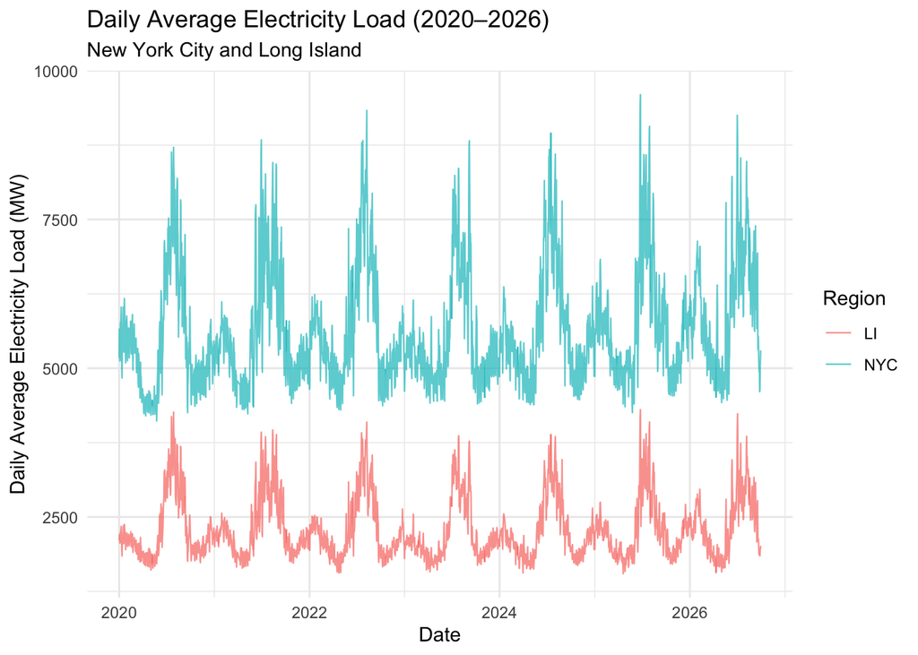

```r
ggplot(combined_data,
       aes(x = DATE,
           y = Daily_Average_Load,
           color = Zone)) +
  geom_line(alpha = 0.7, linewidth = 0.4) +
  labs(
    title = "Daily Average Electricity Load (2020–2026)",
    subtitle = "New York City and Long Island",
    x = "Date",
    y = "Daily Average Electricity Load (MW)",
    color = "Region"
  ) +
  theme_minimal()
```

#### Electricity Load Over Time Findings

The time series visualization illustrates daily average electricity load in New York City and Long Island from January 2020 through September 2026. Both regions exhibit recurring seasonal fluctuations, with noticeable increases in electricity demand during the summer months. These patterns may be associated with increased electricity consumption for air conditioning during warmer weather.

New York City consistently exhibits higher electricity load than Long Island, with an average daily load of approximately 5,655 MW compared with 2,291 MW. NYC also shows greater absolute variability in demand, with a standard deviation of approximately 955 MW compared with 516 MW for Long Island.

Although the two regions differ in overall electricity demand, their seasonal patterns appear similar. Further analysis of temperature and electricity load will help determine whether these seasonal increases are associated with warmer weather.

#### Temperature vs Electricity Load

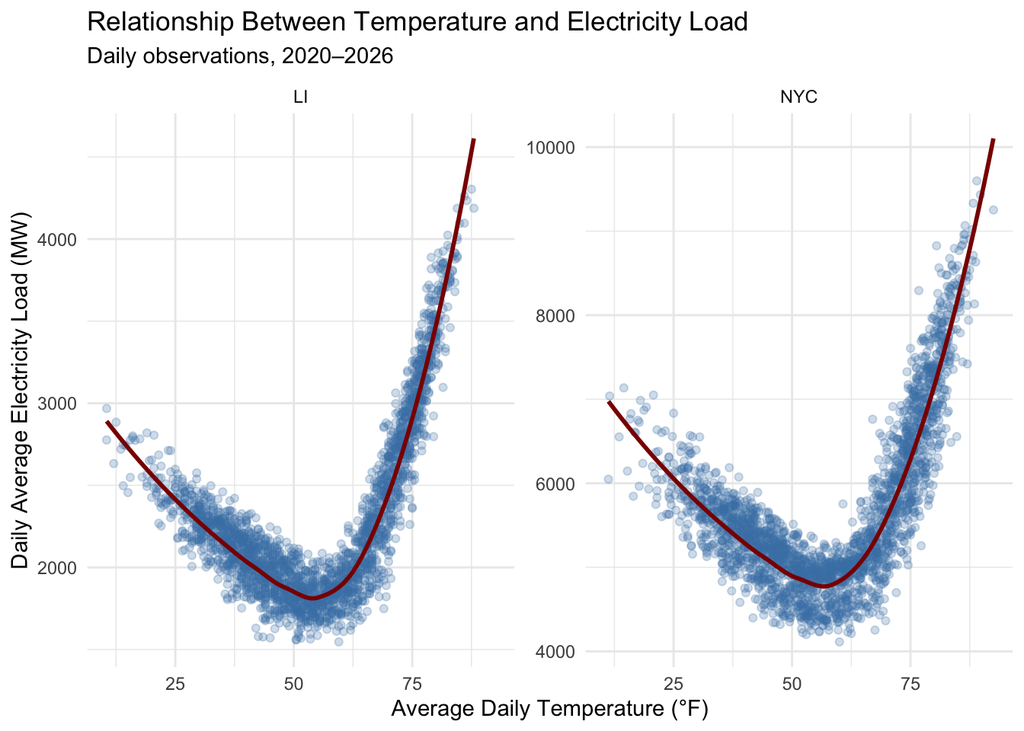

```r
ggplot(combined_data,
       aes(x = TAVG, y = Daily_Average_Load)) +
  geom_point(alpha = 0.25, color = "steelblue") +
  geom_smooth(method = "loess", se = FALSE,
              color = "darkred", linewidth = 1) +
  facet_wrap(~ Zone, scales = "free_y") +
  labs(
    title = "Relationship Between Temperature and Electricity Load",
    subtitle = "Daily observations, 2020–2026",
    x = "Average Daily Temperature (°F)",
    y = "Daily Average Electricity Load (MW)"
  ) +
  theme_minimal()
```

#### Temperature and Electricity Load Analysis

The scatterplots reveal a nonlinear, U-shaped relationship between average daily temperature and electricity load in both New York City and Long Island. Electricity demand is lowest at moderate temperatures, approximately 50–60°F, and increases as temperatures become either colder or warmer.

The increase in electricity load at higher temperatures is particularly pronounced, suggesting that cooling-related electricity consumption may be an important contributor to overall demand. At lower temperatures, electricity load also increases, although the relationship appears less steep.

Despite differences in overall electricity demand, both regions exhibit similar temperature-related patterns. These findings suggest that temperature is associated with electricity demand, although other factors, including seasonal activity, population, and energy consumption patterns, may also contribute to the observed variation.

#### Heating and Cooling Degree Days

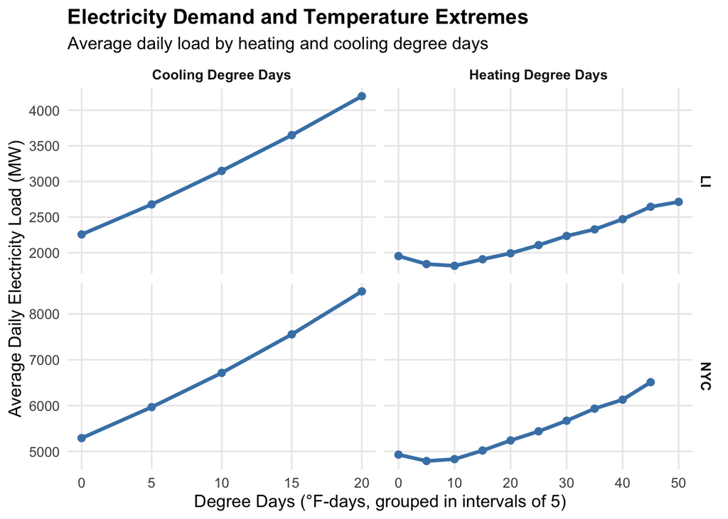

```r
# Prepare heating and cooling degree day data
degree_day_summary <- combined_data %>%
  pivot_longer(
    cols = c(HDD, CDD),
    names_to = "Type",
    values_to = "Degree_Days"
  ) %>%
  filter(Degree_Days > 0) %>%
  mutate(
    Degree_Day_Bin = floor(Degree_Days / 5) * 5,
    Type = recode(
      Type,
      HDD = "Heating Degree Days",
      CDD = "Cooling Degree Days"
    )
  ) %>%
  group_by(Zone, Type, Degree_Day_Bin) %>%
  summarise(
    Average_Load = mean(Daily_Average_Load),
    Days = n(),
    .groups = "drop"
  ) %>%
  filter(Days >= 5)

# Create visualization
ggplot(degree_day_summary,
       aes(x = Degree_Day_Bin, y = Average_Load)) +
  geom_line(color = "steelblue", linewidth = 1.2) +
  geom_point(color = "steelblue", size = 2) +
  facet_grid(Zone ~ Type, scales = "free") +
  labs(
    title = "Electricity Demand and Temperature Extremes",
    subtitle = "Average daily load by heating and cooling degree days",
    x = "Degree Days (°F-days, grouped in intervals of 5)",
    y = "Average Daily Electricity Load (MW)"
  ) +
  theme_minimal(base_size = 12) +
  theme(
    panel.grid.minor = element_blank(),
    strip.text = element_text(face = "bold"),
    plot.title = element_text(face = "bold")
  )
```

#### Heating and Cooling Degree Days Analysis

The visualization examines the relationship between electricity load and heating and cooling degree days in New York City and Long Island. Both regions demonstrate increasing electricity demand as cooling degree days rise, indicating a strong association between warmer temperatures and higher electricity load.

The relationship between heating degree days and electricity demand appears more complex than the cooling related relationship. Although some colder conditions are associated with elevated electricity demand in the degree day visualization, the overall Pearson correlations for heating degree days were negative in both regions. This suggests that the relationship varies across temperature ranges and may be influenced by the substantially higher electricity demand observed during summer.

The findings demonstrate that temperature extremes are associated with higher electricity demand in both regions, with cooling-related demand showing a particularly pronounced pattern. These results are consistent with the nonlinear relationship observed in the earlier temperature-versus-electricity-load scatterplots.

#### Seasonal Electricity Demand

```r
# Assign seasons based on calendar month
seasonal_data <- combined_data %>%
  mutate(
    Season = case_when(
      lubridate::month(DATE) %in% c(12, 1, 2) ~ "Winter",
      lubridate::month(DATE) %in% c(3, 4, 5) ~ "Spring",
      lubridate::month(DATE) %in% c(6, 7, 8) ~ "Summer",
      TRUE ~ "Fall"
    ),
    Season = factor(
      Season,
      levels = c("Winter", "Spring", "Summer", "Fall")
    )
  )

# Calculate average electricity load by season and region
seasonal_summary <- seasonal_data %>%
  group_by(Zone, Season) %>%
  summarise(
    Average_Load = mean(Daily_Average_Load, na.rm = TRUE),
    Days = n(),
    .groups = "drop"
  )

print(seasonal_summary)
```

```
# A tibble: 8 × 4
  Zone  Season Average_Load  Days
  <chr> <fct>         <dbl> <int>
1 LI    Winter        2225.   601
2 LI    Spring        1885.   637
3 LI    Summer        2924.   644
4 LI    Fall          2099.   576
5 NYC   Winter        5551.   601
6 NYC   Spring        4968.   637
7 NYC   Summer        6748.   644
8 NYC   Fall          5301.   576
```

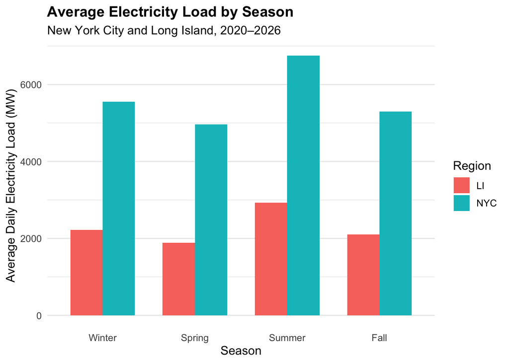

```r
# Create seasonal comparison
ggplot(seasonal_summary,
       aes(x = Season, y = Average_Load, fill = Zone)) +
  geom_col(position = "dodge", width = 0.7) +
  labs(
    title = "Average Electricity Load by Season",
    subtitle = "New York City and Long Island, 2020–2026",
    x = "Season",
    y = "Average Daily Electricity Load (MW)",
    fill = "Region"
  ) +
  theme_minimal(base_size = 12) +
  theme(
    plot.title = element_text(face = "bold"),
    panel.grid.major.x = element_blank()
  )
```

#### Seasonal Electricity Demand Analysis

The seasonal comparison shows that electricity demand varies throughout the year in both New York City and Long Island. Summer has the highest average electricity load in both regions, followed by winter, fall, and spring.

The higher summer demand is consistent with the temperature-related patterns identified in the earlier analyses, where electricity load increased substantially during warmer conditions. Winter also shows elevated electricity demand compared with spring and fall, although the increase is less pronounced than during summer.

New York City consistently exhibits higher average electricity load than Long Island across all four seasons. Despite this difference, both regions follow similar seasonal patterns, suggesting that seasonal weather conditions are associated with electricity demand in both locations.

#### Electricity Load Outlier Analysis

```r
# Calculate outlier thresholds separately for each region
outlier_data <- combined_data %>%
  group_by(Zone) %>%
  mutate(
    Q1 = quantile(Daily_Average_Load, 0.25),
    Q3 = quantile(Daily_Average_Load, 0.75),
    IQR_Load = Q3 - Q1,
    Lower_Bound = Q1 - 1.5 * IQR_Load,
    Upper_Bound = Q3 + 1.5 * IQR_Load,
    Outlier = Daily_Average_Load < Lower_Bound |
              Daily_Average_Load > Upper_Bound
  ) %>%
  ungroup()

# Count outliers by region
outlier_data %>%
  group_by(Zone) %>%
  summarise(
    Total_Observations = n(),
    Outliers = sum(Outlier),
    Outlier_Percent = round(mean(Outlier) * 100, 2),
    .groups = "drop"
  )
```

```
# A tibble: 2 × 4
  Zone  Total_Observations Outliers Outlier_Percent
  <chr>              <int>    <int>           <dbl>
1 LI                  2458      108            4.39
2 NYC                 2458      105            4.27
```

```r
# View potential outliers and their weather conditions
outlier_data %>%
  filter(Outlier) %>%
  select(DATE, Zone, Daily_Average_Load, TAVG, HDD, CDD) %>%
  arrange(desc(Daily_Average_Load)) %>%
  head(15)
```

```
# A tibble: 15 × 6
   DATE       Zone  Daily_Average_Load  TAVG   HDD   CDD
   <date>     <chr>              <dbl> <dbl> <dbl> <dbl>
 1 2025-06-25 NYC                9598.  89       0  24
 2 2025-06-24 NYC                9432.  89.8     0  24.8
 3 2022-08-09 NYC                9332.  88.2     0  23.2
 4 2026-07-02 NYC                9252.  92.5     0  27.5
 5 2025-07-30 NYC                9066.  86.5     0  21.5
 6 2025-07-29 NYC                9018.  88       0  23
 7 2022-08-08 NYC                8961.  86.5     0  21.5
 8 2024-07-16 NYC                8960.  86.2     0  21.2
 9 2026-07-03 NYC                8903.  87.5     0  22.5
10 2025-06-23 NYC                8896.  86.2     0  21.2
11 2021-06-30 NYC                8838   86       0  21
12 2022-07-25 NYC                8826.  80.5     0  15.5
13 2023-09-07 NYC                8823.  85.8     0  20.8
14 2022-07-21 NYC                8794.  84.2     0  19.2
15 2023-09-06 NYC                8768.  85.2     0  20.2
```

#### Check how many flagged observations are associated with particularly warm days

```r
outlier_data %>%
  filter(Outlier) %>%
  group_by(Zone) %>%
  summarise(
    Total_Outliers = n(),
    Hot_Day_Outliers = sum(TAVG >= 80),
    Cold_Day_Outliers = sum(TAVG <= 32),
    .groups = "drop"
  )
```

```
# A tibble: 2 × 4
  Zone  Total_Outliers Hot_Day_Outliers Cold_Day_Outliers
  <chr>          <int>            <int>             <int>
1 LI               108               75                 0
2 NYC              105              101                 0
```

#### Determine whether the flagged observations are above or below the IQR thresholds

```r
outlier_data %>%
  filter(Outlier) %>%
  mutate(
    Outlier_Type = case_when(
      Daily_Average_Load > Upper_Bound ~ "High",
      Daily_Average_Load < Lower_Bound ~ "Low"
    )
  ) %>%
  count(Zone, Outlier_Type)
```

```
# A tibble: 2 × 3
  Zone  Outlier_Type     n
  <chr> <chr>        <int>
1 LI    High           108
2 NYC   High           105
```

#### Outlier Analysis

Potential outliers in daily average electricity load were identified using the interquartile range (IQR) method, with thresholds calculated separately for New York City and Long Island.

The analysis identified 105 high-load outliers in NYC (4.27% of observations) and 108 in Long Island (4.39%). No unusually low electricity-load observations were flagged in either region.

Of the 105 NYC outliers, 101 (96.2%) occurred on days with average temperatures of at least 80°F. Similarly, 75 of Long Island’s 108 outliers (69.4%) occurred on days meeting this temperature threshold. No flagged observations occurred on days with average temperatures at or below 32°F.

These findings indicate that unusually high electricity demand frequently coincides with hot weather, particularly in NYC. The observations are consistent with increased cooling related electricity demand during warmer periods. Because these values may represent legitimate demand peaks rather than data errors, they will be retained for the analysis.

#### Precipitation and Electricity Load

```r
# Compare electricity load on dry and rainy days
precip_summary <- combined_data %>%
  mutate(
    Rain_Category = if_else(
      PRCP > 0, "Rainy", "Dry"
    )
  ) %>%
  group_by(Zone, Rain_Category) %>%
  summarise(
    Average_Load = round(mean(Daily_Average_Load), 2),
    Days = n(),
    .groups = "drop"
  )
print(precip_summary)
```

```
# A tibble: 4 × 4
  Zone  Rain_Category Average_Load  Days
  <chr> <chr>                <dbl> <int>
1 LI    Dry                  2291.  1600
2 LI    Rainy                2290.   858
3 NYC   Dry                  5642.  1548
4 NYC   Rainy                5677.   910
```

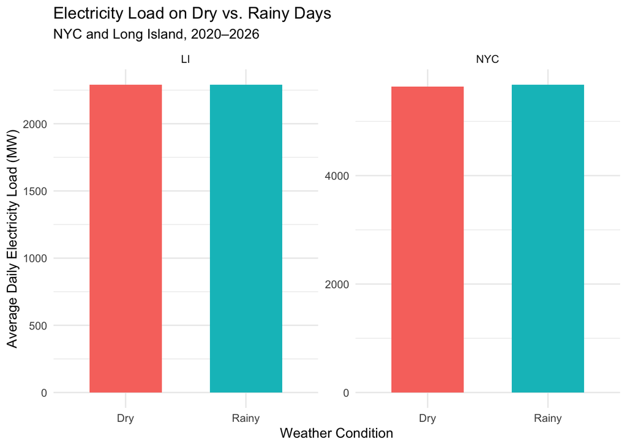

```r
# Visualize results
ggplot(precip_summary,
       aes(x = Rain_Category,
           y = Average_Load,
           fill = Rain_Category)) +
  geom_col(width = 0.6) +
  facet_wrap(~ Zone, scales = "free_y") +
  labs(
    title = "Electricity Load on Dry vs. Rainy Days",
    subtitle = "NYC and Long Island, 2020–2026",
    x = "Weather Condition",
    y = "Average Daily Electricity Load (MW)"
  ) +
  theme_minimal() +
  theme(legend.position = "none")
```

#### Precipitation and Electricity Load Analysis

The analysis compared average daily electricity load between dry days, defined as days with no recorded precipitation, and rainy days, defined as days with recorded precipitation greater than zero.

The results show minimal differences in average electricity load between dry and rainy days in both New York City and Long Island. While NYC exhibits a slightly higher average load on rainy days, the difference is relatively small. Long Island shows almost no noticeable difference between the two categories.

Compared with the stronger relationships observed between temperature and electricity load, precipitation occurrence appears to have a weaker association with daily electricity demand. However, this comparison does not account for rainfall intensity, seasonal patterns, or temperature differences between rainy and dry days.

#### Correlation of Weather and Electricity Demand

```r
# Calculate correlations separately for NYC and LI
correlation_results <- combined_data %>%
  group_by(Zone) %>%
  summarise(
    Correlation_HDD = round(
      cor(HDD, Daily_Average_Load, use = "complete.obs"),
      3
    ),
    Correlation_CDD = round(
      cor(CDD, Daily_Average_Load, use = "complete.obs"),
      3
    ),
    Correlation_PRCP = round(
      cor(PRCP, Daily_Average_Load, use = "complete.obs"),
      3
    ),
    .groups = "drop"
  )

print(correlation_results)
```

```
# A tibble: 2 × 4
  Zone  Correlation_HDD Correlation_CDD Correlation_PRCP
  <chr>           <dbl>           <dbl>            <dbl>
1 LI             -0.332           0.908            0.035
2 NYC            -0.251           0.854            0.061
```

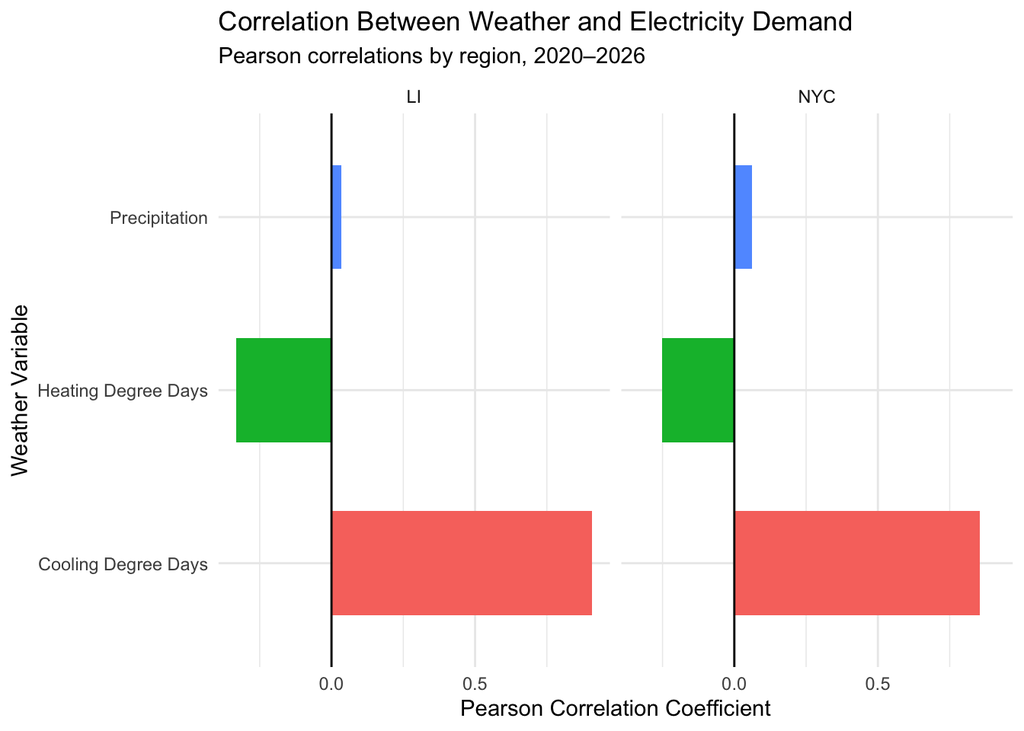

```r
# Prepare correlations for visualization
correlation_plot <- correlation_results %>%
  pivot_longer(
    cols = starts_with("Correlation_"),
    names_to = "Weather_Variable",
    values_to = "Correlation"
  ) %>%
  mutate(
    Weather_Variable = recode(
      Weather_Variable,
      Correlation_HDD = "Heating Degree Days",
      Correlation_CDD = "Cooling Degree Days",
      Correlation_PRCP = "Precipitation"
    )
  )

# Plot correlation coefficients
ggplot(correlation_plot,
       aes(x = Weather_Variable,
           y = Correlation,
           fill = Weather_Variable)) +
  geom_col(width = 0.6) +
  geom_hline(yintercept = 0, color = "black") +
  facet_wrap(~ Zone) +
  coord_flip() +
  labs(
    title = "Correlation Between Weather and Electricity Demand",
    subtitle = "Pearson correlations by region, 2020–2026",
    x = "Weather Variable",
    y = "Pearson Correlation Coefficient"
  ) +
  theme_minimal() +
  theme(legend.position = "none")
```

#### Correlation Analysis

Pearson correlation coefficients were calculated to examine the relationships between heating degree days (HDD), cooling degree days (CDD), precipitation, and daily average electricity load in New York City and Long Island from 2020 through September 2026.

Cooling degree days demonstrated the strongest positive relationship with electricity demand in both regions. Long Island had a correlation coefficient of 0.908, while NYC had a coefficient of 0.854. These results indicate that higher cooling requirements are strongly associated with increased electricity demand, supporting the seasonal and temperature related patterns identified in the earlier visualizations.

Heating degree days showed negative correlations with electricity demand, with coefficients of -0.332 in Long Island and -0.251 in NYC. Although electricity demand may increase during colder conditions, the overall negative correlations suggest that the stronger summer electricity peaks influence the relationship across the full dataset.

Precipitation demonstrated very weak positive correlations with electricity demand, with coefficients of 0.035 in Long Island and 0.061 in NYC. These findings are consistent with the earlier precipitation analysis, which identified minimal differences in average electricity load between rainy and dry days.

The correlation analysis provides additional evidence that cooling related weather conditions have the strongest linear association with electricity demand among the weather variables examined. However, these correlations do not establish causation or account for other factors influencing electricity consumption.

## Conclusion

This exploratory analysis examined the relationship between weather conditions and daily electricity demand in New York City (NYC) and Long Island (LI) from January 2020 through September 2026. Using NOAA weather observations and NYISO electricity load data, the analysis investigated temperature patterns, heating and cooling degree days, seasonal variation, precipitation, and unusually high electricity demand.

The results indicate that temperature, particularly warmer weather, has a strong association with electricity demand in both regions. The temperature scatterplots revealed a nonlinear relationship, with electricity demand generally lowest during moderate temperatures and increasing substantially during hotter conditions. Seasonal comparisons further demonstrated that summer consistently had the highest average electricity load in both NYC and LI.

The correlation analysis provided additional support for these findings. Cooling degree days had a strong positive correlation with electricity demand in Long Island (r = 0.908) and NYC (r = 0.854), suggesting that cooling-related weather conditions are closely associated with increased electricity consumption. Heating degree days demonstrated weaker negative overall correlations, while precipitation showed almost no linear association with electricity load.

The outlier analysis also highlighted the importance of hot weather. Of the 105 unusually high-load observations identified in NYC, 101 occurred on days with average temperatures of at least 80°F. In Long Island, 75 of the 108 high-load outliers occurred under the same conditions. These findings suggest that unusually high electricity demand frequently coincides with extreme heat, particularly in NYC.

Although NYC had substantially higher average electricity demand than Long Island, both regions exhibited similar seasonal and temperature-related patterns. Overall, the analysis suggests that warmer temperatures and increased cooling requirements are the most important weather related indicators of electricity demand among the variables examined. These findings may help inform electricity demand forecasting and seasonal energy planning, although the observed relationships should not be interpreted as evidence of causation.

Several limitations should be considered when interpreting the results of this analysis.

First, the analysis is observational and identifies associations between weather conditions and electricity demand rather than establishing causal relationships. Other factors, including population, economic activity, holidays, electricity prices, and changes in energy consumption behavior, may influence electricity demand but were not included in the analysis.

Second, the weather data were obtained from three monitoring stations, with two stations representing NYC and one representing Long Island. As a result, the measurements may not fully capture weather variation across either region. Averaging the two NYC stations also simplifies local temperature differences.

Third, the electricity dataset contained seven missing dates for each region during the study period. Although the final joined dataset contained no missing values, these dates were absent from the analysis.

Fourth, the precipitation analysis classified observations as rainy or dry based on whether any precipitation was recorded. This approach did not account for precipitation intensity, duration, or differences in temperature and season between rainy and dry days.

Finally, Pearson correlation coefficients measure linear relationships and may not fully represent nonlinear patterns. The temperature scatterplots suggested a U-shaped relationship between temperature and electricity demand, demonstrating that graphical analysis remains important alongside numerical correlations.

Future research could incorporate additional weather stations, humidity, holidays, population, and economic indicators. Statistical modeling could also help determine how much variation in electricity demand can be explained by weather conditions after accounting for other factors.